# House Prices Regression

## Predicting House Prices with Random Forest and XGBoost

This project had the objetive to test different approaches of ensemble models (models composed of week learners, that combined results in a great predictor), to find the one that would best fit a House Pricing Prediction. Here was tested algorithms based on Bagging (bootstrap aggregation) and Boosting mechanisms, and then compared between each other. To know more details about these mechanisms, open this [article by Joseph Rocca](https://towardsdatascience.com/ensemble-methods-bagging-boosting-and-stacking-c9214a10a205). Let's beggin explaining in detail what was done:

- Random Forest and Gradient Boosting are both ensemble Machine Learning methods that fits well many regression problems with ease. Each one of them has its own particularities, and can perform better over different scenarios.
- This Project were built to predict House Selling Prices based on data of houses in an North-American State, considering many features beyond the common-sense (normally used to evaluate houses).

  > The dataset used for training and testing the model is available on Kaggle, and considers 79 features of houses from Iowa (USA).To see the description of each, check the data source on [House Prices dataset](https://www.kaggle.com/competitions/house-prices-advanced-regression-techniques/data)

### 1. Loading the data

First we begin importing the libraries that will be used:

```python
import os #get directories
import pandas as pd #data processing
#libraries for plotting
import matplotlib.pyplot as plt
%matplotlib inline
import seaborn as sns
```

```python
#displaying only Two decimal points for float data
pd.options.display.float_format = '{:,.2f}'.format
```

Next, load the data. Bear in mind that the data is saved on a local directory, and the path written to load it might change if the archive is moved.  
Also, before reading the code, consider some important notes:

- The output we want to predict ( y ) is the house Sale Price . The train data has all the prices the model needs to study, while the test data has not, so the model can make its magic;
- The features ( X ) were selected based on what is expected to increase performance of the chosen models. Basically, we analysed which features were irrelevant and droped them;

```python
print(os.getcwd()) #check were the files are

#load data
df_test = pd.read_csv('C:/Users/Samsung/test.csv')
df_train = pd.read_csv('C:/Users/Samsung/train.csv')
df = pd.concat([df_test, df_train])
pd.merge()
#store in a object only the possible feature cols
feat = df_train.drop(labels = 'SalePrice', axis = 1)
```

[output not shown]

```
C:\Users\Samsung
```

## 2. Explanatory Data Analysis (EDA)

Start describing the data, searching for helpfull insights before we begin building the model:

#### 2.1 Train & test data statistics

First, let's look into the shape of the train/test features DataFrame. Next, we'll look the statistics of numerical columns to find relevant insights, before building the model. For that, the `describe()` method works perfectly.

```python
print('train shape:{}'.format(df_train.shape), '\n test shape:{}'.format(df_test.shape))
#data statistics
df_train.describe(include = ['int64','float64'])
```

```
train shape:(1460, 81)
 test shape:(1459, 80)
```

|  | Id | MSSubClass | LotFrontage | LotArea | OverallQual | OverallCond | YearBuilt | YearRemodAdd | MasVnrArea | BsmtFinSF1 | ... | WoodDeckSF | OpenPorchSF | EnclosedPorch | 3SsnPorch | ScreenPorch | PoolArea | MiscVal | MoSold | YrSold | SalePrice |
| --- | --- | --- | --- | --- | --- | --- | --- | --- | --- | --- | --- | --- | --- | --- | --- | --- | --- | --- | --- | --- | --- |
| count | 1,460.00 | 1,460.00 | 1,201.00 | 1,460.00 | 1,460.00 | 1,460.00 | 1,460.00 | 1,460.00 | 1,452.00 | 1,460.00 | ... | 1,460.00 | 1,460.00 | 1,460.00 | 1,460.00 | 1,460.00 | 1,460.00 | 1,460.00 | 1,460.00 | 1,460.00 | 1,460.00 |
| mean | 730.50 | 56.90 | 70.05 | 10,516.83 | 6.10 | 5.58 | 1,971.27 | 1,984.87 | 103.69 | 443.64 | ... | 94.24 | 46.66 | 21.95 | 3.41 | 15.06 | 2.76 | 43.49 | 6.32 | 2,007.82 | 180,921.20 |
| std | 421.61 | 42.30 | 24.28 | 9,981.26 | 1.38 | 1.11 | 30.20 | 20.65 | 181.07 | 456.10 | ... | 125.34 | 66.26 | 61.12 | 29.32 | 55.76 | 40.18 | 496.12 | 2.70 | 1.33 | 79,442.50 |
| min | 1.00 | 20.00 | 21.00 | 1,300.00 | 1.00 | 1.00 | 1,872.00 | 1,950.00 | 0.00 | 0.00 | ... | 0.00 | 0.00 | 0.00 | 0.00 | 0.00 | 0.00 | 0.00 | 1.00 | 2,006.00 | 34,900.00 |
| 25% | 365.75 | 20.00 | 59.00 | 7,553.50 | 5.00 | 5.00 | 1,954.00 | 1,967.00 | 0.00 | 0.00 | ... | 0.00 | 0.00 | 0.00 | 0.00 | 0.00 | 0.00 | 0.00 | 5.00 | 2,007.00 | 129,975.00 |
| 50% | 730.50 | 50.00 | 69.00 | 9,478.50 | 6.00 | 5.00 | 1,973.00 | 1,994.00 | 0.00 | 383.50 | ... | 0.00 | 25.00 | 0.00 | 0.00 | 0.00 | 0.00 | 0.00 | 6.00 | 2,008.00 | 163,000.00 |
| 75% | 1,095.25 | 70.00 | 80.00 | 11,601.50 | 7.00 | 6.00 | 2,000.00 | 2,004.00 | 166.00 | 712.25 | ... | 168.00 | 68.00 | 0.00 | 0.00 | 0.00 | 0.00 | 0.00 | 8.00 | 2,009.00 | 214,000.00 |
| max | 1,460.00 | 190.00 | 313.00 | 215,245.00 | 10.00 | 9.00 | 2,010.00 | 2,010.00 | 1,600.00 | 5,644.00 | ... | 857.00 | 547.00 | 552.00 | 508.00 | 480.00 | 738.00 | 15,500.00 | 12.00 | 2,010.00 | 755,000.00 |

8 rows × 38 columns

#### 2.2 Response Variable Distribution

Now, take a look into the Sales Price on the Train Data.  
By plotting the Smooth Density, we see that most prices are between 100 and 200 k USD:

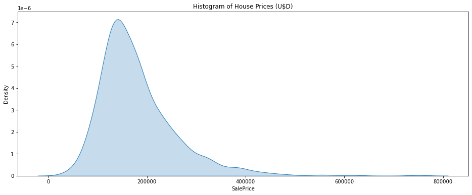

```python
#exploring the response variable:

#defining plot:
plt.figure(figsize=(16,6))
plt.title('Histogram of House Prices (U$D)')
#calling histogram
sns.kdeplot(x= df['SalePrice'], shade = True)
```

#### 2.3 Missing Values

Check if the data has NaN values. Next, look into cathegorical variables to check it's cardinality, wether the train has all of them, or if we might find some new ones at validation

```python
#finding missing values on the training df

#SalePrice
print('How many Nan values at predicted var?\n {}'.format(df_train['SalePrice'].isnull().sum()))

#feature columns:
print('How many missing values on feature cols?\n{}'.format(feat.isna().sum().sum()))
#by cols:
Nan_col = [col for col in feat.columns if feat[col].isnull().any()]
print('\nColumns with missing values: [{}]\n'.format(len(Nan_col)))
print(feat[Nan_col].isnull().sum().sort_values(ascending= False))
```

```
How many Nan values at predicted var?
 0
How many missing values on feature cols?
6965

Columns with missing values: [19]

PoolQC          1453
MiscFeature     1406
Alley           1369
Fence           1179
FireplaceQu      690
LotFrontage      259
GarageType        81
GarageYrBlt       81
GarageFinish      81
GarageQual        81
GarageCond        81
BsmtExposure      38
BsmtFinType2      38
BsmtFinType1      37
BsmtCond          37
BsmtQual          37
MasVnrArea         8
MasVnrType         8
Electrical         1
dtype: int64
```

#### 2.3.1 Filling empty spaces

Looking at the data described, it is time to give some treatment to the information above. The treatment steps are listed bellow:

- PoolQc has the most NaN's for a reason: Not every house has a pool. Thus, it must be replaced by a new cathegory: 'None'.
- the same applies to MiscFeature, Alley, Fence, FireplaceQu,and all Garage and Basement variables;
- For the LotFrontage, Electrical system and Masonry Veener variables, they will be imputed using scikit learn methods;

```python
#replacing empty spaces with the a variable that represents the absence of the feature:

fill_cols = ['PoolQC', 'MiscFeature', 'Alley', 'Fence', 'FireplaceQu', 'GarageType', 'GarageFinish', 'GarageQual', 'GarageCond', 'BsmtFinType1', 'BsmtFinType2', 'BsmtExposure','BsmtCond', 'BsmtQual']

check_list=[]

for col in fill_cols:
    df_train.loc[:,col].fillna(value = 'None', inplace = True)
    df_test.loc[:,col].fillna(value = 'None', inplace = True)
    #check if the operation worked (has Nan == False)
    check_list.append(len(df_train.loc[df_train[col].isna()]) == 0)

#Check if all test_list values are True (Bear in mind: True == 1)!!!
if (sum(check_list) == len(fill_cols)):
    print('All empty values have been replaced!')
else:
    print('Check again')
```

```
All empty values have been replaced!
```

###### Note: If the program returns an error, it is just a warning telling us the values are being replaced on the original DF.

#### 2.4 Reducing High Cardinality

Next, lets check which variables have a high cardinality. This will be important when we start the Encoding process.

> (OBS: it was decided to take analysis only if the cardinality is over 6. Less than that, it would have little influence on the training speed)

```python
cat = [col for col in feat.columns if (feat[col].dtype == 'object')]

high_cdly = {} #high cardinality features (  >6 cathegories)
for i in cat:
    if df_train[i].nunique() > 6:
        high_cdly[i] = df_train[i].nunique()
        print('col_name: {} \n --------- \n'.format(i))
        print(df_train[i].value_counts().sort_values(ascending = False))
```

```
col_name: Neighborhood
 ---------

NAmes      225
CollgCr    150
OldTown    113
Edwards    100
Somerst     86
Gilbert     79
NridgHt     77
Sawyer      74
NWAmes      73
SawyerW     59
BrkSide     58
Crawfor     51
Mitchel     49
NoRidge     41
Timber      38
IDOTRR      37
ClearCr     28
SWISU       25
StoneBr     25
MeadowV     17
Blmngtn     17
BrDale      16
Veenker     11
NPkVill      9
Blueste      2
Name: Neighborhood, dtype: int64
col_name: Condition1
 ---------

Norm      1260
Feedr       81
Artery      48
RRAn        26
PosN        19
RRAe        11
PosA         8
RRNn         5
```

[output cut: 119 more lines]

```
2Types       6
Name: GarageType, dtype: int64
col_name: SaleType
 ---------

WD       1267
New       122
COD        43
ConLD       9
ConLw       5
ConLI       5
CWD         4
Oth         3
Con         2
Name: SaleType, dtype: int64
```

```python
#Print the cat_columns that have a high cardinality:
print(high_cdly)
```

```
{'Neighborhood': 25, 'Condition1': 9, 'Condition2': 8, 'HouseStyle': 8, 'RoofMatl': 8, 'Exterior1st': 15, 'Exterior2nd': 16, 'BsmtFinType1': 7, 'BsmtFinType2': 7, 'Functional': 7, 'GarageType': 7, 'SaleType': 9}
```

###### Points taken:

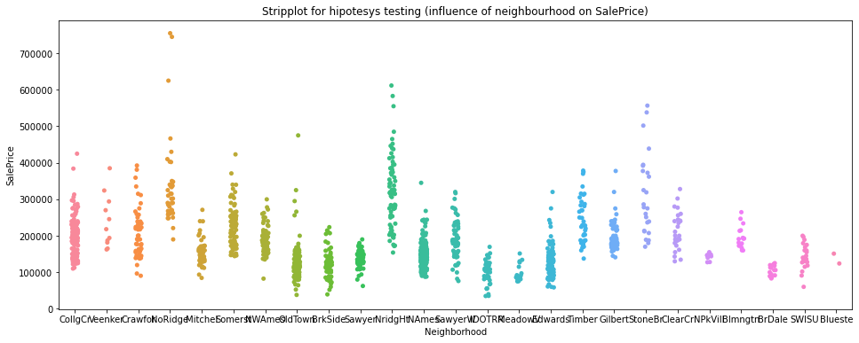

```python
#defining plot:
plt.figure(figsize=(16,6))
plt.title('Stripplot for hipotesys testing (influence of neighbourhood on SalePrice)')
#calling stripplot
sns.stripplot(x = df_train['Neighborhood'], y = df_train['SalePrice'])
```

```python
#dictionary to store which columns to change
ToReplace = {}

#loop to add keys (column names) and values (cathegories to be replaced)
for col_ in high_cdly.keys():
    ValueList = []
    for u in list(df_train[col_].unique()):
        if (df_train[df_train[col_] == u].shape[0] < (0.1*(df_train[col_].shape[0]))):
            ValueList.append(u)
        else:
            continue
    ToReplace[col_] = ValueList

del ValueList
```

```python
#Replacing the cathegories with low presence

for col in ToReplace.keys():
    df_train[col] = df_train[col].replace(ToReplace[col], 'Other')
    df_test[col] = df_test[col].replace(ToReplace[col], 'Other')
```

#### 2.5 Numerical Features Selection

Finally, let's look into which features have trully a considerable correlation to the output variable. For that we will define a new threshold, that is:

- If correlation is bellow 0.35, the variable will be dropped.
- Else, we keep it.

Then, we will create a heatmap visual to assess collinarity between features.

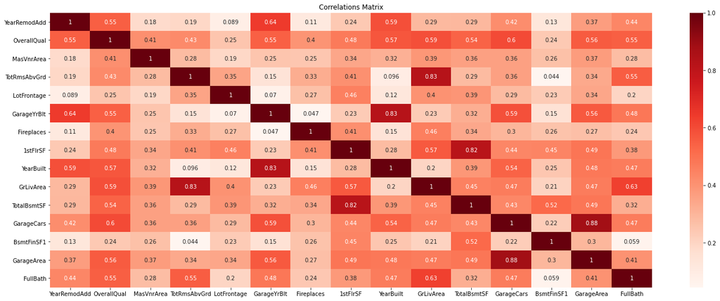

```python
#define a list of numerical columns in dataframe
num_cols = list(set(df_train.columns) - set(cat))

#create a list of those columns acording with the criteria:
ToKeep = [col for col in num_cols if  df_train[col].corr(df_train['SalePrice']) > 0.35]
ToKeep.remove('SalePrice')

#plotting Colinearity heatmap:
dataCor = df_train[ToKeep].corr()

plt.figure(figsize=(24,9))
plt.title('Correlations Matrix')
sns.heatmap(dataCor, annot = True, cmap=plt.cm.Reds)

del dataCor
```

Besides having some inner correlations, it was decided to keep those variables, such as 'OverallQual' and 'GarageCars', as they are very important for the model.

```python
#select the columns to drop:
num_cols.remove('SalePrice')
ToDrop = list(set(num_cols)-set(ToKeep))

#update Training DataFrame:
df_train.drop(ToDrop, axis = 1, inplace = True)
```

## 3. Preprocessing

It is always important to preprocess the information before applying the ML model. We saw that a few columns require imputing values for completeness, and others require encoding for better resulting.  
Here it will be apllied some Preprocessing steps, following the steps:

1. First, split train/test data, then select numerical and cathegorical columns (the last will be split for ordinal and OneHot Encoding);
2. Second, check if there is cathegories in test there are not in training. If so, update the `handle_unknown` parameter at encoding;
3. Next, create pipelines for cathegorical variables: One to be applied to features represented by an ordinal scale, and other to apply on features to be OneHot Encoded;
4. Transform the columns and prepare for modeling;

```python
from sklearn.model_selection import train_test_split

#Select response variable & features
y = df_train['SalePrice']
X = df_train.drop(['SalePrice'], axis = 1)

#define train | valid data
X_train, X_valid, y_train, y_valid = train_test_split(X, y,
                                                      train_size=0.8, test_size=0.2,
                                                      random_state = 1)
```

```python
#see if there are cathegories that are not present on train but are in validation:
del cat
cat = [col for col in X_train.columns if (X_train[col].dtype == 'object')]

IsInTrain = [col for col in cat if set(X_valid[col]).issubset(X_train[col])]
NotInTrain = list(set(cat) - set(IsInTrain))

print('Columns with cathegories not in training:\n {}'.format(NotInTrain))
```

```
Columns with cathegories not in training:
 ['HeatingQC']
```

###### Note: Because at least one column has new cathegory never seen in trainning, we have to add '`use_encoded_value`' as *handle_unknown* argument.

```python
from sklearn.impute import SimpleImputer
from sklearn.preprocessing import OrdinalEncoder, OneHotEncoder
from sklearn.pipeline import Pipeline
from sklearn.compose import ColumnTransformer


#remember that cathegorical ones were already stored at 'cat' object, and numerical at 'ToKeep' object)
num = ToKeep #changing the column name to ease further understanding

#break cat_cols into ones to be OH and Ordinal encoded:
OE_cat = ['LotShape', 'LandContour', 'Utilities', 'LandSlope', 'ExterQual', 'ExterCond', 'BsmtQual', 'BsmtCond', 'BsmtExposure', 'BsmtFinType1', 'BsmtFinType2', 'HeatingQC', 'CentralAir', 'KitchenQual', 'Functional', 'FireplaceQu', 'GarageFinish', 'GarageQual', 'GarageCond', 'PoolQC', 'Fence']
OH_cat = list(set(cat) - set(OE_cat))


#Create pipeline for imputing and encoding cathegorical variables (OBS: select the ones for OneHot and Oordinal Enc.)
num_transf = SimpleImputer(strategy = 'mean')

OE_transf = Pipeline(steps = [
    ('Impute', SimpleImputer(strategy = 'most_frequent')),
    ('O_Encoder', OrdinalEncoder(handle_unknown = 'use_encoded_value', unknown_value = 26))
])

OH_transf = Pipeline(steps = [
    ('Imput', SimpleImputer(strategy = 'most_frequent')),
    ('OH_Encoder', OneHotEncoder(sparse = False, handle_unknown = 'ignore'))
])


#Make a transformer for preprocess numercial and cathegorical cols
preprocessor = ColumnTransformer(transformers = [
    ('num_transf', num_transf, num),
    ('OE_transf', OE_transf, OE_cat),
    ('OH_transf', OH_transf, OH_cat)
])
```

## 4. Random Forest Regressor

Now we implement the Random Forest Regression algorithm. We begin importing the `RandomForestRegressor()` method from scikit learn, and then create the final pipeline that will preprocess and build the model. Next, we use scikit-learn to predict and evaluate the model.  
*Note: It was assigned 850 decision trees to compose the RF model based on experience, but later this number will be tuned*

```python
from sklearn.ensemble import RandomForestRegressor
from sklearn.metrics import mean_absolute_error

#create model object:

RFmodel = RandomForestRegressor(n_estimators = 850,
                               criterion = 'mse')

RF_Pipeline = Pipeline(steps= [
    ('preprocessing', preprocessor),
    ('modeling', RFmodel)
])

RF_Pipeline.fit(X_train, y_train)
RFpred = RF_Pipeline.predict(X_valid)

RFscore = mean_absolute_error(RFpred, y_valid)
print('Mean Absolute Error:\n{:.2f}'.format(RFscore))
```

```
Mean Absolute Error:
16672.46
```

This `Mean Absolute Error` means the expected error, in US dollars, of our prediction VS the real value, which gives us a good margin, considering the difference to the prices in our data. Now we have a reference to enhance the model accuracy.

For instance, we can check visually with a regression line:

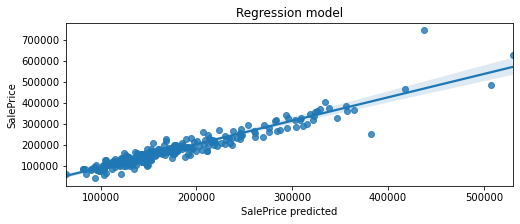

```python
plt.figure(figsize = (8,3))
plt.xlabel('SalePrice predicted')
plt.title('Regression model')
sns.regplot(x = RFpred, y= y_valid)
```

#### 4.1 Improve Performance

Considerations:

- Looking into the last regression plot, it looks like the 'SalePrice' data distribution might look a little different with higher prices! By using the `stats` module, we can check the if the predicted variable fits a normal distribution on all of its data. If not, we can transform the data for this.
- Because we do not know which parameters to set, we will define a function to try a set of estimators, and use the set with the least loss.

```
((array([-3.30513952, -3.04793228, -2.90489705, ...,  2.90489705,
          3.04793228,  3.30513952]),
  array([ 34900,  35311,  37900, ..., 625000, 745000, 755000], dtype=int64)),
 (74160.16474519417, 180921.19589041095, 0.9319665641512986))
```

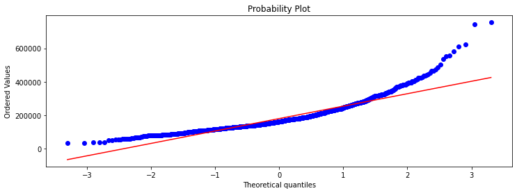

```python
from scipy import stats #module that allows to make statistical tests!
import numpy as np

#plotting the graph
plt.figure(figsize = (12, 4))
stats.probplot(x = y, dist = 'norm', plot = plt)
```

###### - The first assumption is true. One way to correct it, is applying a log-transformation into the predicted variable. If we do this, the result improves a lot:

```
((array([-3.30513952, -3.04793228, -2.90489705, ...,  2.90489705,
          3.04793228,  3.30513952]),
  array([10.46024211, 10.47194981, 10.54270639, ..., 13.34550693,
         13.5211395 , 13.53447303])),
 (0.39826223081618867, 12.024050901109383, 0.9953761475636611))
```

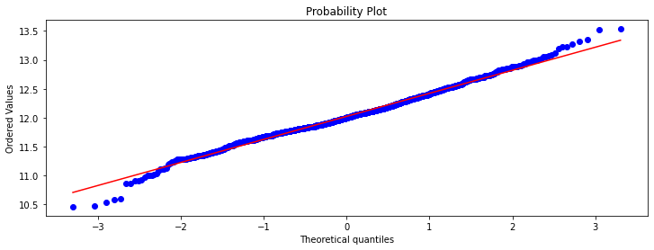

```python
#ln tranform:
y = np.log(y)

#plotting the graph
plt.figure(figsize = (12, 4))
stats.probplot(x = y, dist = 'norm', plot = plt)
```

- Considering this, we will transform the train and test responses to fit the model in a log scale. Then, to evaluate the model, we apply a reverse log-transformation.

```python
#Transform y_train and y_valid:
y_train, y_valid = np.log(y_train), np.log(y_valid)
```

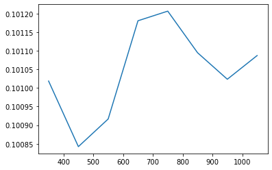

```python
Results = {}

#define funtion to store metrics value
def mae_scoring(n_tree):
    ppl = Pipeline(steps=[
        ('prep', preprocessor),
        ('mod', RandomForestRegressor(n_estimators = n_tree,
                                     criterion = 'mse', random_state = 1))
    ])
    ppl.fit(X_train, y_train)
    RF_preds = ppl.predict(X_valid)
    #store the results in a dictionary(for later)
    Results[n_tree] = RF_preds

    #get the mean absolute error:
    return mean_absolute_error(y_valid, RF_preds)

#store the data on a dictionary object
Optimal_finding = {tree:mae_scoring(tree) for tree in list(range(350, 1051, 100))}

plt.plot(list(Optimal_finding.keys()),
         list(Optimal_finding.values()))
plt.show()
```

Great!! we got the best model at 450 trees. Let's check the results of our RF model:

```
loss (mae):
 0.10084218511327964
CORRELATION :
 0.9384627181000369
```

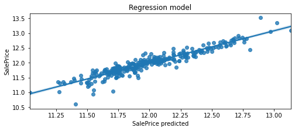

```python
plt.figure(figsize = (8,3))
plt.xlabel('SalePrice predicted')
plt.title('Regression model (log scale)')
sns.regplot(x = Results[450], y= y_valid)

cor_df = pd.DataFrame({'predicted': Results[450], 'real': y_valid})
print('loss (mae):\n {}'.format(Optimal_finding[450]))
print('CORRELATION :\n {}'.format(cor_df['predicted'].corr(cor_df['real'])))

del cor_df
```

## 5. Extreme Gradient Boosting Regressor

- Last, we'll do the same for XGRegressor. This algorithm, like RandomForests, is an ensemble model, though the difference resides that it does not runs algorithms in parallel, it learns sequentially, by adapting the mistakes from each previous week learner.

```python
from xgboost import XGBRegressor


GBmodel = XGBRegressor(n_estimators = 1000, learning_rate = 0.05, n_jobs =2)

#encoding data:
GBtransformer = preprocessor.fit(X_train)
X_train = GBtransformer.transform(X_train)
X_valid = GBtransformer.transform(X_valid)

#fitting
GBmodel.fit(X_train, y_train,
            eval_set=[(X_valid, y_valid)],
            early_stopping_rounds = 5,
            verbose = False
           )

#predict
GBpred = GBmodel.predict(X_valid)

#evaluate
GBscore = mean_absolute_error(GBpred, y_valid)
print('gradient boosting scoring: {}'.format(GBscore))
```

```
gradient boosting scoring:0.09702269791527932
```

- As expected, this algorithm provided even better results, although it took longer to converge (as expected). Finally, we can look into the combined model (the average prediction of both models, compared with the real data)

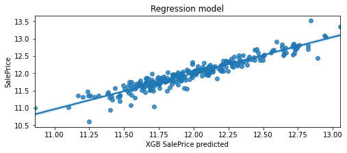

```python
plt.figure(figsize = (8,3))
plt.xlabel('XGB SalePrice predicted')
plt.title('Regression model (log scale)')
sns.regplot(x = GBpred, y= y_valid)
```

## 6. Models combined

- Here is where the models are finally compared. First, we apply the inverse log-transformation into the predictions. Then, a thrid model is created, with a stack of the same weight from both bagging and boosting algorithms. Finally, we make visual representations of the data distributions and regression plots, of each model VS testing values.
- To end, we calculate the % error, in USD, of each model. With this, we know if the model suits our expectations.

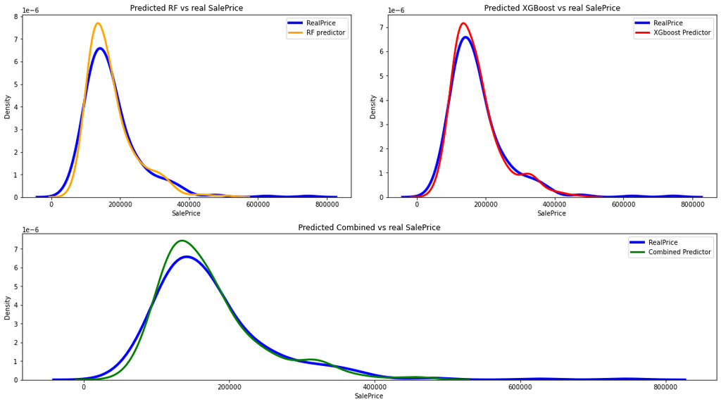

```python
#get the exponentials to return it to the real values:

#RF predictions:
model_1= np.exp(Results[450])

#XGB predicitons
model_2= np.exp(GBpred)

#models combined
model_3 = (model_1 / 2) + (model_2 / 2)

#real value:
y_real = np.exp(y_valid)

#plot Random Forest Model
fig = plt.figure(figsize = (16,8))
ax1 = fig.add_axes([0,0.5, 0.45, 0.5])
plt.title('Predicted RF vs real SalePrice', size = 12)
sns.kdeplot(x = y_real, label = 'RealPrice', color = 'blue', linewidth = 4, ax = ax1)
sns.kdeplot(x = model_1, label = 'RF predictor', color = 'orange', linewidth = 3, ax = ax1)
plt.legend()

#plot XGBoost model
ax2 = fig.add_axes([0.5, 0.5, 0.45, 0.5])
plt.title('Predicted XGBoost vs real SalePrice', size = 12)
sns.kdeplot(x = y_real, label = 'RealPrice', color = 'blue', linewidth = 4, ax = ax2)
sns.kdeplot(x = model_2, label = 'XGboost Predictor', color = 'red', linewidth = 3, ax = ax2)
plt.legend()

#plot composed model
ax3 = fig.add_axes([0,0, 0.95, 0.4])
plt.title('Predicted Combined vs real SalePrice', size = 12)
sns.kdeplot(x = y_real, label = 'RealPrice', color = 'blue', linewidth = 4, ax = ax3)
sns.kdeplot(x = model_3, label = 'Combined Predictor', color = 'green', linewidth = 3, ax = ax3)
plt.legend()
```

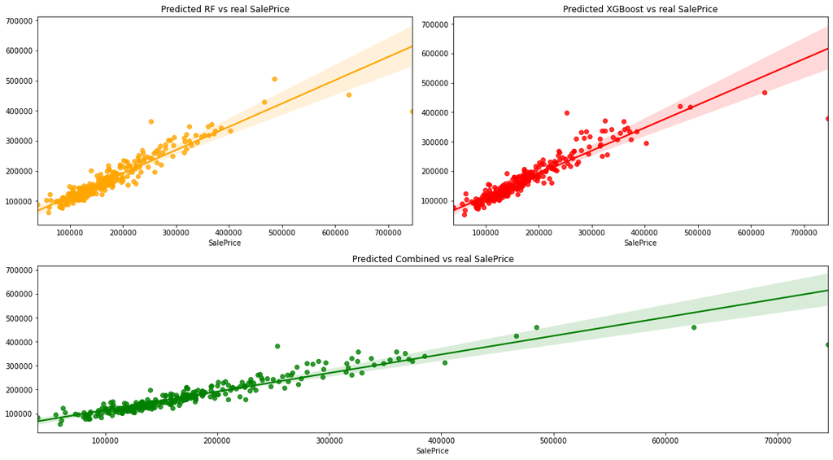

```python
fig = plt.figure(figsize = (16,8))
ax1 = fig.add_axes([0,0.5, 0.45, 0.5])
plt.title('Predicted RF vs real SalePrice', size = 12)
sns.regplot(x = y_real, y = model_1, color = 'orange', ax = ax1)


#plot XGBoost model
ax2 = fig.add_axes([0.5, 0.5, 0.45, 0.5])
plt.title('Predicted XGBoost vs real SalePrice', size = 12)
sns.regplot(x = y_real, y = model_2, color = 'red', ax = ax2)


#plot composed model
ax3 = fig.add_axes([0,0, 0.95, 0.4])
plt.title('Predicted Combined vs real SalePrice', size = 12)
sns.regplot(x = y_real, y = model_3, color = 'green', ax = ax3)
```

```python
print('expected difference of Real Price VS Model Prediction: \n--------------')
print("1. RF MAE:  {:.2%}".format((mean_absolute_error(model_1, y_real)/np.mean(y_real))))

print("2. XGBoost MAE:  {:.2%}".format((mean_absolute_error(model_2, y_real)/np.mean(y_real))))

print("3. Combined MAE:  {:.2%}".format((mean_absolute_error(model_3, y_real)/np.mean(y_real))))
```

```
expected difference of Real Price VS Model Prediction:
--------------
1. RF MAE:  9.90%
2. XGBoost MAE:  9.86%
3. Combined MAE:  9.51%
```

### 7. Conclusion

To summarize, we got a accurate model predicting house prices in Ames, Iowa, by using the following:

- **Feature Engineering**: Selecting the right features is never easy, but here we managed to organize the data to provide the its best for the models. First, organizing cahtegorical columns, and then selecting the numerical from a correlation's matrix.
- **Preprocessing**: Imputation and Encoding had a strong impact in the model's performance.
- **logaritmal transformation**: The output data had a strong dispertion from the normal distribution on its tails. By log-transforming it, we were able to reach much better regression lines.
- **Model selection**: By applying different machine learning models, we could compare which ones would deploy better results, even combining them.